# analysis

```r
library(zmarket)
library(dplyr)
```

```r
library(ggplot2)
library(magrittr)
library(purrr)
```

This document contains a simple exploration and modeling of the Sleep App data provided by Gradient Metrics. Our main sources are Harrel (2001) and Rao (2014).

# Exploratory data analysis

To examine the experimental design, we calculate an index of all levels of discrete variables using all other discrete variables as grouping variables. For a level of a discrete variable, this index with respect to the level of another grouping variable is equal to its frequency in that level of the grouping variable divided by its frequency across all levels of the grouping variable times 100.

```r
discrete_vars <- experiment_data %>% select(duration:social_proof)
indtabs <- list()
i <- 1
cat("## Tables of indexes\n Groups levels are on rows and index levels are on columns.")
```

## Tables of indexes

Groups levels are on rows and index levels are on columns.

```r
for(v1 in names(discrete_vars)){
  for(v2 in setdiff(names(discrete_vars), v1)){
    indtabs[[i]] <- index(experiment_data[[v1]], experiment_data[[v2]])
    print(knitr::kable(indtabs[[i]]))
    i <- i + 1
  }
}
```

|  | 12 months | 3 months | 6 months |
| --- | --- | --- | --- |
| give you the energy to unlock your fullest potential | 102.27794 | 92.46102 | 105.14090 |
| help you lead a better life | 100.91452 | 105.02264 | 94.24799 |
| help you sleep without more pills | 99.22461 | 99.78708 | 100.94863 |
| improve your health for the long-run | 94.58288 | 104.30241 | 101.00534 |
| improve your sleep sustainably | 102.97490 | 98.58805 | 98.52467 |

|  | 12 months | 3 months | 6 months |
| --- | --- | --- | --- |
| breaking bad habits and creating new routines | 97.50151 | 99.88576 | 102.50144 |
| changing your sleep mindset | 101.66171 | 100.92512 | 97.51181 |
| empowering you to take back your sleep habits | 100.81944 | 99.17225 | 100.01972 |

|  | 12 months | 3 months | 6 months |
| --- | --- | --- | --- |
| $20/month | 98.86928 | 98.52521 | 102.51388 |
| $30/month | 103.66156 | 97.74260 | 98.68863 |
| $40/month | 97.48480 | 103.69774 | 98.81597 |

|  | 12 months | 3 months | 6 months |
| --- | --- | --- | --- |
| a program created just for you | 98.07587 | 101.11484 | 100.75847 |
| cognitive behavioral therapy | 104.35670 | 95.05526 | 100.63295 |
| daily text messages from a coach | 97.85194 | 99.82564 | 102.22453 |
| personalized, human coaching | 105.91100 | 96.37118 | 97.86806 |
| the support of a community of people just like you | 93.73238 | 105.27924 | 100.87059 |
| unique daily games, challenges and exercises | 99.73057 | 102.74436 | 97.59300 |

|  | 12 months | 3 months | 6 months |
| --- | --- | --- | --- |
| a method that has helped thousands | 100.34013 | 99.53991 | 100.12131 |
| leading researchers | 102.58803 | 93.22057 | 104.10668 |
| professional athletes | 98.64810 | 105.65066 | 95.80665 |
| scientific evidence | 98.51104 | 101.39452 | 100.07052 |

|  | give you the energy to unlock your fullest potential | help you lead a better life | help you sleep without more pills | improve your health for the long-run | improve your sleep sustainably |
| --- | --- | --- | --- | --- | --- |
| 12 months | 102.27794 | 100.91452 | 99.22461 | 94.58288 | 102.97490 |
| 3 months | 92.46102 | 105.02264 | 99.78708 | 104.30241 | 98.58805 |
| 6 months | 105.14090 | 94.24799 | 100.94863 | 101.00534 | 98.52467 |

|  | give you the energy to unlock your fullest potential | help you lead a better life | help you sleep without more pills | improve your health for the long-run | improve your sleep sustainably |
| --- | --- | --- | --- | --- | --- |
| breaking bad habits and creating new routines | 104.87784 | 93.19478 | 98.96022 | 99.55181 | 103.36335 |
| changing your sleep mindset | 98.67769 | 105.17903 | 98.52093 | 99.77652 | 97.76546 |
| empowering you to take back your sleep habits | 96.44193 | 101.56660 | 102.55273 | 100.67843 | 98.89449 |

|  | give you the energy to unlock your fullest potential | help you lead a better life | help you sleep without more pills | improve your health for the long-run | improve your sleep sustainably |
| --- | --- | --- | --- | --- | --- |
| $20/month | 101.87077 | 99.15702 | 98.49114 | 100.64761 | 99.73945 |
| $30/month | 97.42282 | 99.63012 | 100.71420 | 99.15994 | 103.24731 |
| $40/month | 100.70767 | 101.20035 | 100.78300 | 100.19330 | 97.03559 |

|  | give you the energy to unlock your fullest potential | help you lead a better life | help you sleep without more pills | improve your health for the long-run | improve your sleep sustainably |
| --- | --- | --- | --- | --- | --- |
| a program created just for you | 97.14434 | 101.39200 | 98.91892 | 104.24847 | 98.30994 |
| cognitive behavioral therapy | 94.38094 | 98.51798 | 105.96856 | 98.62498 | 102.89959 |
| daily text messages from a coach | 109.68026 | 93.55493 | 94.14858 | 97.54873 | 104.78411 |
| personalized, human coaching | 103.42915 | 96.41818 | 96.24148 | 105.76769 | 97.92360 |
| the support of a community of people just like you | 98.95545 | 101.33882 | 97.38072 | 102.28919 | 99.99688 |
| unique daily games, challenges and exercises | 96.71444 | 108.94821 | 107.07828 | 91.43021 | 95.94534 |

|  | give you the energy to unlock your fullest potential | help you lead a better life | help you sleep without more pills | improve your health for the long-run | improve your sleep sustainably |
| --- | --- | --- | --- | --- | --- |
| a method that has helped thousands | 102.48683 | 100.55153 | 97.42969 | 99.36095 | 100.03049 |
| leading researchers | 97.49349 | 94.32658 | 101.37221 | 101.45037 | 105.63548 |
| professional athletes | 95.84840 | 107.97262 | 99.29432 | 98.98399 | 97.91091 |
| scientific evidence | 104.02093 | 97.04108 | 101.93404 | 100.24483 | 96.62194 |

|  | breaking bad habits and creating new routines | changing your sleep mindset | empowering you to take back your sleep habits |
| --- | --- | --- | --- |
| 12 months | 97.50151 | 101.66171 | 100.81944 |
| 3 months | 99.88576 | 100.92512 | 99.17225 |
| 6 months | 102.50144 | 97.51181 | 100.01972 |

|  | breaking bad habits and creating new routines | changing your sleep mindset | empowering you to take back your sleep habits |
| --- | --- | --- | --- |
| give you the energy to unlock your fullest potential | 104.87784 | 98.67769 | 96.44193 |
| help you lead a better life | 93.19478 | 105.17903 | 101.56660 |
| help you sleep without more pills | 98.96022 | 98.52093 | 102.55273 |
| improve your health for the long-run | 99.55181 | 99.77652 | 100.67843 |
| improve your sleep sustainably | 103.36335 | 97.76546 | 98.89449 |

|  | breaking bad habits and creating new routines | changing your sleep mindset | empowering you to take back your sleep habits |
| --- | --- | --- | --- |
| $20/month | 99.29271 | 102.59745 | 98.06466 |
| $30/month | 101.80043 | 98.89066 | 99.31974 |
| $40/month | 98.91282 | 98.53289 | 102.58820 |

|  | breaking bad habits and creating new routines | changing your sleep mindset | empowering you to take back your sleep habits |
| --- | --- | --- | --- |
| a program created just for you | 106.64614 | 94.97530 | 98.43613 |
| cognitive behavioral therapy | 102.08349 | 98.83992 | 99.08678 |
| daily text messages from a coach | 96.51464 | 100.12014 | 103.38265 |
| personalized, human coaching | 100.70498 | 101.06568 | 98.20518 |
| the support of a community of people just like you | 97.00206 | 103.30052 | 99.65187 |
| unique daily games, challenges and exercises | 96.64790 | 101.99591 | 101.33735 |

|  | breaking bad habits and creating new routines | changing your sleep mindset | empowering you to take back your sleep habits |
| --- | --- | --- | --- |
| a method that has helped thousands | 100.62391 | 100.30113 | 99.06573 |
| leading researchers | 102.56020 | 94.61944 | 102.90776 |
| professional athletes | 98.19315 | 104.00994 | 97.73121 |
| scientific evidence | 98.70372 | 100.91202 | 100.37432 |

|  | $20/month | $30/month | $40/month |
| --- | --- | --- | --- |
| 12 months | 98.86928 | 103.66156 | 97.48480 |
| 3 months | 98.52521 | 97.74260 | 103.69774 |
| 6 months | 102.51388 | 98.68863 | 98.81597 |

|  | $20/month | $30/month | $40/month |
| --- | --- | --- | --- |
| give you the energy to unlock your fullest potential | 101.87077 | 97.42282 | 100.70767 |
| help you lead a better life | 99.15702 | 99.63012 | 101.20035 |
| help you sleep without more pills | 98.49114 | 100.71420 | 100.78300 |
| improve your health for the long-run | 100.64761 | 99.15994 | 100.19330 |
| improve your sleep sustainably | 99.73945 | 103.24731 | 97.03559 |

|  | $20/month | $30/month | $40/month |
| --- | --- | --- | --- |
| breaking bad habits and creating new routines | 99.29271 | 101.80043 | 98.91282 |
| changing your sleep mindset | 102.59745 | 98.89066 | 98.53289 |
| empowering you to take back your sleep habits | 98.06466 | 99.31974 | 102.58820 |

|  | $20/month | $30/month | $40/month |
| --- | --- | --- | --- |
| a program created just for you | 95.47893 | 103.71874 | 100.77971 |
| cognitive behavioral therapy | 103.47583 | 97.12859 | 99.41287 |
| daily text messages from a coach | 97.61108 | 98.61277 | 103.73806 |
| personalized, human coaching | 99.26062 | 104.48690 | 96.27903 |
| the support of a community of people just like you | 102.66035 | 97.24107 | 100.10744 |
| unique daily games, challenges and exercises | 101.53965 | 98.76855 | 99.69978 |

|  | $20/month | $30/month | $40/month |
| --- | --- | --- | --- |
| a method that has helped thousands | 102.77608 | 94.84053 | 102.37486 |
| leading researchers | 98.07822 | 105.09549 | 96.84408 |
| professional athletes | 97.87892 | 102.57183 | 99.54509 |
| scientific evidence | 101.17265 | 97.70867 | 101.11420 |

|  | a program created just for you | cognitive behavioral therapy | daily text messages from a coach | personalized, human coaching | the support of a community of people just like you | unique daily games, challenges and exercises |
| --- | --- | --- | --- | --- | --- | --- |
| 12 months | 98.07587 | 104.35670 | 97.85194 | 105.91100 | 93.73238 | 99.73057 |
| 3 months | 101.11484 | 95.05526 | 99.82564 | 96.37118 | 105.27924 | 102.74436 |
| 6 months | 100.75847 | 100.63295 | 102.22453 | 97.86806 | 100.87059 | 97.59300 |

|  | a program created just for you | cognitive behavioral therapy | daily text messages from a coach | personalized, human coaching | the support of a community of people just like you | unique daily games, challenges and exercises |
| --- | --- | --- | --- | --- | --- | --- |
| give you the energy to unlock your fullest potential | 97.14434 | 94.38094 | 109.68026 | 103.42915 | 98.95545 | 96.71444 |
| help you lead a better life | 101.39200 | 98.51798 | 93.55493 | 96.41818 | 101.33882 | 108.94821 |
| help you sleep without more pills | 98.91892 | 105.96856 | 94.14858 | 96.24148 | 97.38072 | 107.07828 |
| improve your health for the long-run | 104.24847 | 98.62498 | 97.54873 | 105.76769 | 102.28919 | 91.43021 |
| improve your sleep sustainably | 98.30994 | 102.89959 | 104.78411 | 97.92360 | 99.99688 | 95.94534 |

|  | a program created just for you | cognitive behavioral therapy | daily text messages from a coach | personalized, human coaching | the support of a community of people just like you | unique daily games, challenges and exercises |
| --- | --- | --- | --- | --- | --- | --- |
| breaking bad habits and creating new routines | 106.64614 | 102.08349 | 96.51464 | 100.70498 | 97.00206 | 96.6479 |
| changing your sleep mindset | 94.97530 | 98.83992 | 100.12014 | 101.06568 | 103.30052 | 101.9959 |
| empowering you to take back your sleep habits | 98.43613 | 99.08678 | 103.38265 | 98.20518 | 99.65187 | 101.3373 |

|  | a program created just for you | cognitive behavioral therapy | daily text messages from a coach | personalized, human coaching | the support of a community of people just like you | unique daily games, challenges and exercises |
| --- | --- | --- | --- | --- | --- | --- |
| $20/month | 95.47893 | 103.47583 | 97.61108 | 99.26062 | 102.66035 | 101.53965 |
| $30/month | 103.71874 | 97.12859 | 98.61277 | 104.48690 | 97.24107 | 98.76855 |
| $40/month | 100.77971 | 99.41287 | 103.73806 | 96.27903 | 100.10744 | 99.69978 |

|  | a program created just for you | cognitive behavioral therapy | daily text messages from a coach | personalized, human coaching | the support of a community of people just like you | unique daily games, challenges and exercises |
| --- | --- | --- | --- | --- | --- | --- |
| a method that has helped thousands | 98.65663 | 95.31453 | 98.03059 | 105.17876 | 109.41750 | 93.83714 |
| leading researchers | 97.28584 | 106.94664 | 102.06680 | 101.60521 | 91.29436 | 100.30319 |
| professional athletes | 100.23742 | 102.86167 | 103.23826 | 92.63731 | 92.84313 | 107.95053 |
| scientific evidence | 103.70494 | 95.17645 | 96.78602 | 100.56370 | 106.03696 | 98.00518 |

|  | a method that has helped thousands | leading researchers | professional athletes | scientific evidence |
| --- | --- | --- | --- | --- |
| 12 months | 100.34013 | 102.58803 | 98.64810 | 98.51104 |
| 3 months | 99.53991 | 93.22057 | 105.65066 | 101.39452 |
| 6 months | 100.12131 | 104.10668 | 95.80665 | 100.07052 |

|  | a method that has helped thousands | leading researchers | professional athletes | scientific evidence |
| --- | --- | --- | --- | --- |
| give you the energy to unlock your fullest potential | 102.48683 | 97.49349 | 95.84840 | 104.02093 |
| help you lead a better life | 100.55153 | 94.32658 | 107.97262 | 97.04108 |
| help you sleep without more pills | 97.42969 | 101.37221 | 99.29432 | 101.93404 |
| improve your health for the long-run | 99.36095 | 101.45037 | 98.98399 | 100.24483 |
| improve your sleep sustainably | 100.03049 | 105.63548 | 97.91091 | 96.62194 |

|  | a method that has helped thousands | leading researchers | professional athletes | scientific evidence |
| --- | --- | --- | --- | --- |
| breaking bad habits and creating new routines | 100.62391 | 102.56020 | 98.19315 | 98.70372 |
| changing your sleep mindset | 100.30113 | 94.61944 | 104.00994 | 100.91202 |
| empowering you to take back your sleep habits | 99.06573 | 102.90776 | 97.73121 | 100.37432 |

|  | a method that has helped thousands | leading researchers | professional athletes | scientific evidence |
| --- | --- | --- | --- | --- |
| $20/month | 102.77608 | 98.07822 | 97.87892 | 101.17265 |
| $30/month | 94.84053 | 105.09549 | 102.57183 | 97.70867 |
| $40/month | 102.37486 | 96.84408 | 99.54509 | 101.11420 |

|  | a method that has helped thousands | leading researchers | professional athletes | scientific evidence |
| --- | --- | --- | --- | --- |
| a program created just for you | 98.65663 | 97.28584 | 100.23742 | 103.70494 |
| cognitive behavioral therapy | 95.31453 | 106.94664 | 102.86167 | 95.17645 |
| daily text messages from a coach | 98.03059 | 102.06680 | 103.23826 | 96.78602 |
| personalized, human coaching | 105.17876 | 101.60521 | 92.63731 | 100.56370 |
| the support of a community of people just like you | 109.41750 | 91.29436 | 92.84313 | 106.03696 |
| unique daily games, challenges and exercises | 93.83714 | 100.30319 | 107.95053 | 98.00518 |

All index values are close to 100, which means that these variables do not have strong correlations in the overall data set. That is consistent with the description of the experiment as 12 random permutations of a message with 6 attributes.

## Further exploration of design

Next we reproduce a result from the assignment to allow us to comment on it.

```r
(levs <- experiment_data %>%
  select(duration:social_proof) %>%
  map(unique) %>%  map(~t(t(.x))))
```

```
#> $duration
#>      [,1]
#> [1,] "3 months"
#> [2,] "6 months"
#> [3,] "12 months"
#>
#> $offer
#>      [,1]
#> [1,] "help you lead a better life"
#> [2,] "improve your sleep sustainably"
#> [3,] "give you the energy to unlock your fullest potential"
#> [4,] "help you sleep without more pills"
#> [5,] "improve your health for the long-run"
#>
#> $outcome
#>      [,1]
#> [1,] "changing your sleep mindset"
#> [2,] "breaking bad habits and creating new routines"
#> [3,] "empowering you to take back your sleep habits"
#>
#> $price
#>      [,1]
#> [1,] "$30/month"
#> [2,] "$40/month"
#> [3,] "$20/month"
#>
#> $rtb
#>      [,1]
#> [1,] "cognitive behavioral therapy"
#> [2,] "daily text messages from a coach"
#> [3,] "a program created just for you"
#> [4,] "the support of a community of people just like you"
#> [5,] "unique daily games, challenges and exercises"
#> [6,] "personalized, human coaching"
#>
#> $social_proof
#>      [,1]
#> [1,] "leading researchers"
#> [2,] "a method that has helped thousands"
#> [3,] "professional athletes"
#> [4,] "scientific evidence"
```

There are 6 attributes in the experiment with between three and six levels. If we use a dummy variable encoding of each attribute, our model would have 18 parameters. Therefore, it is not reasonable for us to fit such a model for each individual respondent. Therefore, a key modeling challenge will be fit models with relatively large numbers of parameters from relatively small numbers of observations. Our main tools will be to try to pool individuals into homogeneous groups and fit models for those groups and to apply penalties to model parameters to reduce their estimation variance.

## Removal of validation set

To avoid overfitting, we remove 2 tasks from each respondent. We will later use this reserved data for model validation.

```r
set.seed(1)
wdat <- experiment_data %>% group_by(response_id) %>% slice_sample(n = 10) %>%
  mutate(foldid = 1:n())
vdat <- experiment_data %>% anti_join(wdat, by = c("response_id", "task"))
```

## Examination of response variable

To get an idea about the heterogeneity in among respondents, we’ll look at some summary statistics of the distribution of their answers across the ten tasks in our working data.

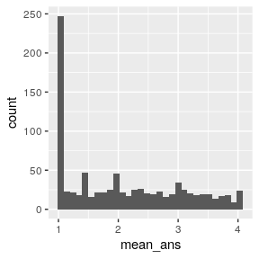

```r
rstats <- wdat %>% group_by(response_id) %>%
  summarise(mean_ans = mean(answer),
            sd_ans = sd(answer),
            max_ans = max(answer),
            min_ans = min(answer),
            range_ans = max_ans  - min_ans)

rstats %>% ggplot(aes(x = mean_ans)) + geom_histogram()
```

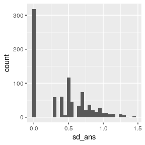

```r
rstats %>% ggplot(aes(x = sd_ans)) + geom_histogram()
```

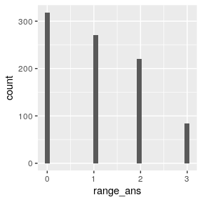

```r
rstats %>% ggplot(aes(x = range_ans)) + geom_histogram()
```

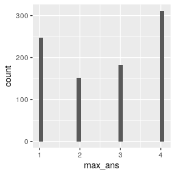

```r
rstats %>% ggplot(aes(x = max_ans)) + geom_histogram()
```

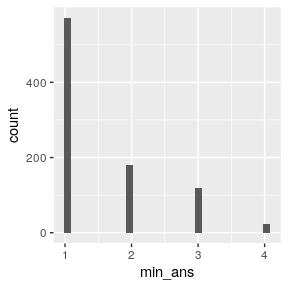

```r
rstats %>% ggplot(aes(x = min_ans)) + geom_histogram()
```

The number of respondents in the sample was a decreasing function of the range of respondents. Ranges of 3 were even rarer than extrapolation of the linear trend from ranges of 0 to 2 would predict. Although rare, the sensitivity of these individuals to some attributes in the experiment may be valuable to know.

On balance the mean answers from the respondents that did not always answer 1 seem to be uniformly distributed. There may be more variation among groups of individuals than within individuals. This variation maybe explainable in terms of variables included in the survey.

# Modeling

As a starting point, we’ll fit a CR (continuation ratio) model (Harrell 2001) that assumes homogeneity among respondents. According to Rao (2014), this homogeneity assumption is rarely satisfied but accounting for heterogeneity with an overly complex model could produce results that do not generalize beyond the training data and are difficult to interpret. Additionally, our time for this analysis is highly limited. Therefore, we will start with a simple model and build up complexity towards an optimal level. The continuation ratio model is a very simple model that is appropriate for an ordinal response variable.

```r
u <- with(wdat, rms::cr.setup(answer))

Y <- u$y

crdat <- wdat[u$subs, ] %>% ungroup() %>% select(task, response_id, foldid, duration:social_proof)
crdat$cohort <- u$cohort

attach(crdat)
m1 <- rms::lrm(Y ~ cohort + duration + offer + outcome + price + rtb + social_proof)
detach(crdat)

m1
```

```
#> Logistic Regression Model
#>
#>  rms::lrm(formula = Y ~ cohort + duration + offer + outcome +
#>      price + rtb + social_proof)
#>
#>                         Model Likelihood    Discrimination    Rank Discrim.
#>                               Ratio Test           Indexes          Indexes
#>  Obs         17138    LR chi2     480.47    R2       0.037    C       0.598
#>   0           9516    d.f.            20    g        0.377    Dxy     0.195
#>   1           7622    Pr(> chi2) <0.0001    gr       1.458    gamma   0.195
#>  max |deriv| 4e-13                          gp       0.092    tau-a   0.096
#>                                             Brier    0.240
#>
#>                                                         Coef    S.E.   Wald Z
#>  Intercept                                              -0.5291 0.0695 -7.61
#>  cohort=answer>=2                                       -0.1976 0.0361 -5.47
#>  cohort=answer>=3                                        0.6649 0.0424 15.69
#>  duration=3 months                                      -0.0394 0.0385 -1.02
#>  duration=6 months                                       0.0291 0.0383  0.76
#>  offer=help you lead a better life                      -0.0039 0.0487 -0.08
#>  offer=help you sleep without more pills                -0.0180 0.0492 -0.37
#>  offer=improve your health for the long-run             -0.0456 0.0490 -0.93
#>  offer=improve your sleep sustainably                    0.0036 0.0495  0.07
#>  outcome=changing your sleep mindset                     0.0627 0.0380  1.65
#>  outcome=empowering you to take back your sleep habits   0.1070 0.0385  2.78
#>  price=$30/month                                         0.2747 0.0380  7.23
#>  price=$40/month                                         0.3550 0.0383  9.27
#>  rtb=cognitive behavioral therapy                        0.0301 0.0531  0.57
#>  rtb=daily text messages from a coach                    0.1088 0.0543  2.00
#>  rtb=personalized, human coaching                        0.0117 0.0539  0.22
#>  rtb=the support of a community of people just like you  0.1190 0.0546  2.18
#>  rtb=unique daily games, challenges and exercises        0.0966 0.0541  1.79
#>  social_proof=leading researchers                       -0.1121 0.0445 -2.52
#>  social_proof=professional athletes                     -0.0126 0.0443 -0.29
#>  social_proof=scientific evidence                       -0.1206 0.0440 -2.74
#>                                                         Pr(>|Z|)
#>  Intercept                                              <0.0001
#>  cohort=answer>=2                                       <0.0001
#>  cohort=answer>=3                                       <0.0001
#>  duration=3 months                                      0.3057
#>  duration=6 months                                      0.4477
#>  offer=help you lead a better life                      0.9364
#>  offer=help you sleep without more pills                0.7150
#>  offer=improve your health for the long-run             0.3519
#>  offer=improve your sleep sustainably                   0.9416
#>  outcome=changing your sleep mindset                    0.0991
#>  outcome=empowering you to take back your sleep habits  0.0054
#>  price=$30/month                                        <0.0001
#>  price=$40/month                                        <0.0001
#>  rtb=cognitive behavioral therapy                       0.5717
#>  rtb=daily text messages from a coach                   0.0451
#>  rtb=personalized, human coaching                       0.8276
#>  rtb=the support of a community of people just like you 0.0295
#>  rtb=unique daily games, challenges and exercises       0.0740
#>  social_proof=leading researchers                       0.0117
#>  social_proof=professional athletes                     0.7756
#>  social_proof=scientific evidence                       0.0062
#>
```

```r
anova(m1)
```

```
#>                 Wald Statistics          Response: Y
#>
#>  Factor       Chi-Square d.f. P
#>  cohort       361.61      2   <.0001
#>  duration       3.27      2   0.1950
#>  offer          1.32      4   0.8573
#>  outcome        7.82      2   0.0201
#>  price         95.68      2   <.0001
#>  rtb            9.49      5   0.0910
#>  social_proof  12.55      3   0.0057
#>  TOTAL        464.42     20   <.0001
```

This model does not fit particularly well, but even so there are several statistically significant variables. The most important appears to be the cohort variable, followed by price and social proof.

We’ll use prediction performance on the validation data as our main metric to compare this model with later models. We will use the log loss, equivalent to the negative log likelihood, of the model on the validation data as our specific metric.

```r
valu <- with(vdat, rms::cr.setup(answer))

val_crdat <- vdat[valu$subs, ] %>% ungroup() %>% select(response_id, duration:social_proof)
val_crdat$cohort <- valu$cohort
val_crdat$y <- valu$y

calc_val_logloss <- function(mod, valdata){
  vdf <- as.data.frame(valdata) # tibbles cause errors because predictrms uses [,i] to select vectors
  p <- predict(mod, vdf, type = "fitted")
  -sum(log(ifelse(vdf$y == 1, p, 1 - p)))
}

validation_log_losses <- list()

(validation_log_losses$m1 <- calc_val_logloss(m1, val_crdat))
```

```
#> [1] 2307.095
```

## Relaxation of CR assumptions

Next we will try relaxing the assumption in the CR model that parameters are the same in all cohorts. Said differently, we’ll relax the assumption that all attributes have the same effect on ratings no matter whether the rating is greater than 1, 2, or 3. We’ve already seen that many 1 responses are from individuals who do seem to be affected by any attributes, so this assumption seems poor.

```r
attach(crdat)
m2 <- rms::lrm(Y ~ cohort*(duration + offer + outcome + price + rtb + social_proof), x = TRUE, y = TRUE)
detach(crdat)

m2
```

```
#> Logistic Regression Model
#>
#>  rms::lrm(formula = Y ~ cohort * (duration + offer + outcome +
#>      price + rtb + social_proof), x = TRUE, y = TRUE)
#>
#>                         Model Likelihood    Discrimination    Rank Discrim.
#>                               Ratio Test           Indexes          Indexes
#>  Obs         17138    LR chi2     554.90    R2       0.043    C       0.602
#>   0           9516    d.f.            56    g        0.414    Dxy     0.203
#>   1           7622    Pr(> chi2) <0.0001    gr       1.512    gamma   0.203
#>  max |deriv| 2e-12                          gp       0.100    tau-a   0.100
#>                                             Brier    0.239
#>
#>                                                                            Coef
#>  Intercept                                                                 -0.4793
#>  cohort=answer>=2                                                          -0.3579
#>  cohort=answer>=3                                                           0.6117
#>  duration=3 months                                                         -0.1004
#>  duration=6 months                                                         -0.0278
#>  offer=help you lead a better life                                         -0.0608
#>  offer=help you sleep without more pills                                   -0.0787
#>  offer=improve your health for the long-run                                -0.0920
#>  offer=improve your sleep sustainably                                      -0.0190
#>  outcome=changing your sleep mindset                                        0.0467
#>  outcome=empowering you to take back your sleep habits                      0.1557
#>  price=$30/month                                                            0.2853
#>  price=$40/month                                                            0.4609
#>  rtb=cognitive behavioral therapy                                          -0.0417
#>  rtb=daily text messages from a coach                                       0.1580
#>  rtb=personalized, human coaching                                          -0.0073
#>  rtb=the support of a community of people just like you                     0.0901
#>  rtb=unique daily games, challenges and exercises                           0.0505
#>  social_proof=leading researchers                                          -0.1420
#>  social_proof=professional athletes                                        -0.0048
#>  social_proof=scientific evidence                                          -0.1164
#>  cohort=answer>=2 * duration=3 months                                       0.0807
#>  cohort=answer>=3 * duration=3 months                                       0.2010
#>  cohort=answer>=2 * duration=6 months                                       0.1363
#>  cohort=answer>=3 * duration=6 months                                       0.0993
#>  cohort=answer>=2 * offer=help you lead a better life                       0.0611
```

[output cut: 191 more lines]

```
#>  cohort=answer>=2 * rtb=daily text messages from a coach                   0.6045
#>  cohort=answer>=3 * rtb=daily text messages from a coach                   0.1777
#>  cohort=answer>=2 * rtb=personalized, human coaching                       0.4097
#>  cohort=answer>=3 * rtb=personalized, human coaching                       0.6343
#>  cohort=answer>=2 * rtb=the support of a community of people just like you 0.1833
#>  cohort=answer>=3 * rtb=the support of a community of people just like you 0.3938
#>  cohort=answer>=2 * rtb=unique daily games, challenges and exercises       0.5903
#>  cohort=answer>=3 * rtb=unique daily games, challenges and exercises       0.3518
#>  cohort=answer>=2 * social_proof=leading researchers                       0.9350
#>  cohort=answer>=3 * social_proof=leading researchers                       0.1627
#>  cohort=answer>=2 * social_proof=professional athletes                     0.7622
#>  cohort=answer>=3 * social_proof=professional athletes                     0.4540
#>  cohort=answer>=2 * social_proof=scientific evidence                       0.6605
#>  cohort=answer>=3 * social_proof=scientific evidence                       0.4909
#>
```

```r
anova(m2)
```

```
#>                 Wald Statistics          Response: Y
#>
#>  Factor                                               Chi-Square d.f. P
#>  cohort  (Factor+Higher Order Factors)                429.18     38   <.0001
#>   All Interactions                                     74.01     36   0.0002
#>  duration  (Factor+Higher Order Factors)                8.97      6   0.1754
#>   All Interactions                                      5.60      4   0.2313
#>  offer  (Factor+Higher Order Factors)                   7.82     12   0.7987
#>   All Interactions                                      6.50      8   0.5912
#>  outcome  (Factor+Higher Order Factors)                14.75      6   0.0223
#>   All Interactions                                      7.18      4   0.1268
#>  price  (Factor+Higher Order Factors)                 128.84      6   <.0001
#>   All Interactions                                     33.13      4   <.0001
#>  rtb  (Factor+Higher Order Factors)                    22.01     15   0.1075
#>   All Interactions                                     12.75     10   0.2382
#>  social_proof  (Factor+Higher Order Factors)           20.40      9   0.0156
#>   All Interactions                                      8.02      6   0.2367
#>  cohort * duration  (Factor+Higher Order Factors)       5.60      4   0.2313
#>  cohort * offer  (Factor+Higher Order Factors)          6.50      8   0.5912
#>  cohort * outcome  (Factor+Higher Order Factors)        7.18      4   0.1268
#>  cohort * price  (Factor+Higher Order Factors)         33.13      4   <.0001
#>  cohort * rtb  (Factor+Higher Order Factors)           12.75     10   0.2382
#>  cohort * social_proof  (Factor+Higher Order Factors)   8.02      6   0.2367
#>  TOTAL INTERACTION                                     74.01     36   0.0002
#>  TOTAL                                                533.34     56   <.0001
```

```r
(validation_log_losses$m2 <- calc_val_logloss(m2, val_crdat))
```

```
#> [1] 2301.713
```

Cohort has a significant interaction with price, and overall is significant. However, the log loss of this much more complicated model is only marginally lower. We have gained very little for a great increase in model complexity. Next, we’ll try to find a more optimal level of complexity with penalized maximum likelihood.

```r
(pt <- rms::pentrace(m2, list(simple = 0, interaction = seq(0, 4000, by = 100))))
```

```
#>
#> Best penalty:
#>
#>  simple interaction      df
#>       0        2000 38.1955
#>
#>  simple interaction       df      aic        bic    aic.c
#>       0           0 56.00000 442.8968   8.949842 442.5231
#>       0         100 53.83937 446.9443  29.740107 446.5986
#>       0         200 52.05233 449.8888  46.532453 449.5655
#>       0         300 50.52533 452.1228  60.599272 451.8181
#>       0         400 49.19150 453.8640  72.676412 453.5750
#>       0         500 48.00772 455.2460  83.231600 454.9706
#>       0         600 46.94432 456.3565  92.582404 456.0931
#>       0         700 45.97995 457.2563 100.955212 457.0036
```

[output cut: 33 more lines]

The best model seems to have twice as many degrees of freedom as our first model, but is much simpler than our second model.

```r
attach(crdat)
m3 <- update(m2, penalty = list(simple = 0, interaction = 2000))
detach(crdat)

(validation_log_losses$m3 <- calc_val_logloss(m3, val_crdat))
```

```
#> [1] 2302.458
```

Interestingly, this model does not have lower loss the m2 in our validation data. But the difference may not be statistically significant, and m3 is considerably simpler:

```r
rms::effective.df(m3)
```

```
#>
#> Original and Effective Degrees of Freedom
#>
#>                          Original Penalized
#> All                            56      38.2
#> Simple Terms                   20      20.0
#> Interaction or Nonlinear       36      18.2
#> Nonlinear                       0       0.0
#> Interaction                    36      18.2
#> Nonlinear Interaction           0       0.0
```

## Relaxation of homogeneneity assumptions

We’ll now try building up complexity by removing the assumption of homogeneity among respondents. We will model this first by allowing the intercept term for each respondent to vary. The full model is unlikely to be optimal so we’ll again use penalized maximum likelihood to determine a more optimal level of model complexity. In fact, I am not able to fit an unpenalized model on my system due to numerical problems which appear to be caused by large variances.

```r
attach(crdat)
m4 <- rms::lrm(Y ~ cohort + response_id + duration + offer + outcome + price + rtb + social_proof, x = TRUE, y = TRUE, penalty = list(simple = 10))
detach(crdat)

anova(m4)
```

```
#>                 Wald Statistics          Response: Y
#>
#>  Factor       Chi-Square d.f. P
#>  cohort        709.62      2  <.0001
#>  response_id  2202.23    891  <.0001
#>  duration        2.17      2  0.3378
#>  offer           0.71      4  0.9505
#>  outcome         5.50      2  0.0640
#>  price         123.76      2  <.0001
#>  rtb            10.67      5  0.0583
#>  social_proof   10.82      3  0.0127
#>  TOTAL        2626.78    911  <.0001
```

```r
(validation_log_losses$m4 <- calc_val_logloss(m4, val_crdat))
```

```
#> [1] 1937.005
```

As expected from our EDA, variation among respondents explains a lot of the variation in the outcomes. Our log loss in the validation data has gone down considerably now that our model can account for the individual providing the answer. As a next step, we’ll try optimizing the penalty to some extent. We could use rms::pentrace again for this but the time required to fit models with rms::lrm is becoming a source of friction in our analysis. Thus, next we try using glmnet for fitting logistic regression models with L1-regularization. The L1 component has the added benefit of encouraging sparsity in the model fit. This will have the effect of grouping some respondents with similar intercept into a homogeneous cluster. We also opt for L1 rather than elastic net regularization because there are no correlations in our predictive variables.

```r
library(glmnet)
require(doMC)
registerDoMC(cores = 2)

m6 <- glmnet::glmnet(m4$x, m4$y, family = "binomial", alpha = 0.8)

foldid <- crdat$foldid

system.time(cvfit <- cv.glmnet(m4$x, m4$y, foldid = foldid, family = "binomial", type.measure = "deviance", parallel = TRUE))
```

```
#>    user  system elapsed
#> 549.714   3.603 339.007
```

```r
newx <- rms::lrm(y ~ cohort + response_id + duration + offer + outcome + price + rtb + social_proof, method = "model.matrix", data = val_crdat)
stopifnot(all(colnames(newx) == colnames(m4$X)))

pcvfit <- predict(cvfit, newx = newx, s = "lambda.min", type = "response") %>% as.numeric()
(validation_log_losses$m5 <- -sum(log(ifelse(val_crdat$y == 1, pcvfit, 1 - pcvfit))))
```

```
#> [1] 1251.216
```

```r
colnames(newx)[which(coef(cvfit, s = "lambda.min") == 0)]
```

```
#>  [1] "response_id=R_0W0F8pBDpQZPjUt"
#>  [2] "response_id=R_10O7AdmClrqxyNv"
#>  [3] "response_id=R_1gTlB1CSMmjb6vO"
#>  [4] "response_id=R_1kNSSg1aT2QzFak"
#>  [5] "response_id=R_1lntx0EmZ8gTdpP"
#>  [6] "response_id=R_20OQaUaLAK9trrY"
#>  [7] "response_id=R_25v9doMkkErDhDG"
#>  [8] "response_id=R_2cilDTqBqGWg6fW"
#>  [9] "response_id=R_2CvodkpRWUT6KwI"
#> [10] "response_id=R_2UhMsSQElvveN4D"
#> [11] "response_id=R_3fT8QqXHJKoBuOh"
#> [12] "response_id=R_3kG8aZY42qaKD4q"
#> [13] "response_id=R_3kpRDrOhZ6MyJ9z"
#> [14] "response_id=R_3KvddGPVl4v0y23"
#> [15] "response_id=R_3QGhYt8HnvxkPtW"
#> [16] "response_id=R_8uzhG5XxTLduno5"
#> [17] "offer=improve your sleep sustainably"
#> [18] "outcome=changing your sleep mindset"
```

# References

Harrell, Frank E. 2001. *Regression Modeling Strategies: With Applications to Linear Models, Logistic Regression, and Survival Analysis*. Corrected edition. New York: Springer.

Rao. 2014. *Applied Conjoint Analysis*. 2014th edition. New York: Springer.